# Updates to the R Documentation System

Andrew Redd, R documentation Task Force

UseR!2017

# History

- UseR!2016
- July 2016, R Consortium Funding
- September-December 2016
- January 2017 - Now

# Design Principles

- Full class system for documentation
- Can document anything
- stored in `attr(., 'documentation')` for traditional objects;
  - functions, data.frames, etc.
- Stored as a meta object similar to class definitions for S4 and reference classes.
- Everything can be accessed or set from the `documentation` and `documentation<-` generics.
- Formats for input and output support decided
- Independent of but supports the package system

# Many in - Many Out

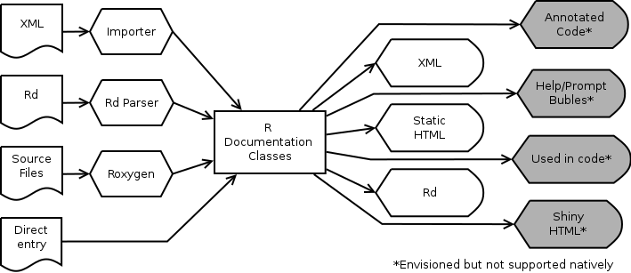

Many in - Many out approach.

# Current State

- `parsetools`
- `documentation`
- `documentation-md`
- `documentation-yaml`

# `parsetools`

```r
library(parsetools)
options(keep.source=TRUE)
pd <- get_parse_data(parse(text="x <- rnorm(100)"))
kable(pd[c(-1,-3)])
```

|  | col1 | col2 | id | parent | token | terminal | text |
| --- | --- | --- | --- | --- | --- | --- | --- |
| 1 | 1 | 1 | 1 | 3 | SYMBOL | TRUE | x |
| 3 | 1 | 1 | 3 | 14 | expr | FALSE |  |
| 14 | 1 | 15 | 14 | 0 | expr | FALSE |  |
| 2 | 3 | 4 | 2 | 14 | LEFT_ASSIGN | TRUE | <- |
| 4 | 6 | 10 | 4 | 6 | SYMBOL_FUNCTION_CALL | TRUE | rnorm |
| 6 | 6 | 10 | 6 | 12 | expr | FALSE |  |
| 12 | 6 | 15 | 12 | 14 | expr | FALSE |  |
| 5 | 11 | 11 | 5 | 12 | ‘(’ | TRUE | ( |
| 7 | 12 | 14 | 7 | 8 | NUM_CONST | TRUE | 100 |
| 8 | 12 | 14 | 8 | 12 | expr | FALSE |  |
| 9 | 15 | 15 | 9 | 12 | ‘)’ | TRUE | ) |

```r
get_pd_assign_value(pd) %>% select(-starts_with('line')) %>% kable
```

|  | col1 | col2 | id | parent | token | terminal | text |
| --- | --- | --- | --- | --- | --- | --- | --- |
| 4 | 6 | 10 | 4 | 6 | SYMBOL_FUNCTION_CALL | TRUE | rnorm |
| 6 | 6 | 10 | 6 | 12 | expr | FALSE |  |
| 12 | 6 | 15 | 12 | 14 | expr | FALSE |  |
| 5 | 11 | 11 | 5 | 12 | ‘(’ | TRUE | ( |
| 7 | 12 | 14 | 7 | 8 | NUM_CONST | TRUE | 100 |
| 8 | 12 | 14 | 8 | 12 | expr | FALSE |  |
| 9 | 15 | 15 | 9 | 12 | ‘)’ | TRUE | ) |

```r
get_pd_assign_variable(pd) %>% select(-starts_with('line')) %>% kable
```

|  | col1 | col2 | id | parent | token | terminal | text |
| --- | --- | --- | --- | --- | --- | --- | --- |
| 1 | 1 | 1 | 1 | 3 | SYMBOL | TRUE | x |
| 3 | 1 | 1 | 3 | 14 | expr | FALSE |  |

# `documentation`

```r
library(documentation)
x <- new('Documentation'
        , title       = "Example documentation"
        , author      = person('Andrew', 'Redd')
        , description = "This is used to demonstrate the class" %\%
                        "system for the documentation package in R"
        , keywords    = "documentation"
        )
```

```r
str(x)
```

```
## Formal class 'Documentation' [package "documentation"] with 10 slots
##   ..@ author     :Class 'person'  hidden list of 1
##   .. ..$ :List of 5
##   .. .. ..$ given  : chr "Andrew"
##   .. .. ..$ family : chr "Redd"
##   .. .. ..$ role   : NULL
##   .. .. ..$ email  : NULL
##   .. .. ..$ comment: NULL
##   ..@ title      : chr "Example documentation"
##   ..@ description:Formal class 'FormattedText' [package "documentation"] with 1 slot
##   .. .. ..@ .Data: chr "This is used to demonstrate the class system for the documentation package in R"
##   ..@ references : list()
##   .. ..- attr(*, "class")= chr "bibentry"
##   ..@ seealso    :Formal class 'FormattedText' [package "documentation"] with 1 slot
##   .. .. ..@ .Data: chr(0)
##   ..@ examples   :Formal class 'Prose' [package "documentation"] with 1 slot
##   .. .. ..@ .Data: list()
##   ..@ keywords   :Formal class 'Documentation-Keyword' [package "documentation"] with 1 slot
##   .. .. ..@ .Data: chr "documentation"
##   ..@ aliases    : chr(0)
##   ..@ concepts   : chr(0)
##   ..@ sections   :Formal class 'SectionList' [package "documentation"] with 1 slot
##   .. .. ..@ .Data: list()
```

```r
toRd(x) %>% cat(sep='\n')
```

```
## \author{Andrew Redd}
## \title{Example documentation}
## \description{This is used to demonstrate the class system for the documentation package in R}
## \keyword{documentation}
```

# Something a bit more interesting

```r
hw <- function(){print("hello world")}
documentation(hw) <- function_documentation('hw', title = "the standard Hello world")
documentation(hw) %>% toRd %>% unlist %>% cat(sep='\n')
```

```
## \name{hw}
## \usage{hw()}
## \value{NA}
## \title{the standard Hello world}
```

# Can your documentation do this?

```r
make_hello <- function(what = 'world'){
  documented(function(){
    print(paste("hello", what))
  }, name  = paste0("hello_", what)
   , title = sprintf("the dynamic hello_%s example", what)
   , description = "Prints hello" %\% what %\%"to the console." %\n%
                   "Used to show the power of dynamic documentation."
   )
}
hello_world <- make_hello()
hello_belgium <- make_hello('Belgium')

hello_belgium()
```

```
## [1] "hello Belgium"
```

```r
documentation(hello_belgium) %>% toRd %>% unlist %>% cat(sep="\n")
```

```
## \name{hello_Belgium}
## \usage{hello_Belgium()}
## \value{NA}
## \title{the dynamic hello_Belgium example}
## \description{Prints hello Belgium to the console.
## Used to show the power of dynamic documentation.}
```

# Test extraction

Example R code in “./R/hello.R”

```r
hello_belgium <- make_hello('Belgium')
if(FALSE){#@testing
  expect_output(hello_belgium(), "hello Belgium")
}
```

We run `extract_tests()` then …

in “./tests/testthat/test-hello.R” we will have

```r
#! This file was automatically produced by documentation on 2017-07-05 11:00:00
#! changes will be overwritten.
context('tests extracted from file `./R/hello.R`')
test_that("hello_belgium", {#@testing
  expect_output(hello_belgium(), "hello Belgium")
})
```

# Something still to finish

**Relational Tags**

```r
hw <-
function( greet = "Hello" #< A greeting
        , who   = "World" #< who to greet.
        ){
    #! A more complicated hello world
    print(paste(greet, who))
    #< Called for the side effect of printing,
    #^ but returns the pasted arguments invisibly.
}
```

# State in summary

| Documentation Classes | done..*ish* |
| --- | --- |
| `parsetools` | functionally Complete |
| test extraction | done |
| Relational Tags | Infrastructure in place |
|  | Needs to integrate with Roxygen |
| **Input Forms** | Lots to do |
| **Output Forms** |  |
| *Rd* | in place, could use improvement |
| *markdown* | lots to do |
| *Others* | not started |

# how people can help and get involved.

- Make a github request for a feature.
- Code one of the missing functionalities
  - code it up
  - test the heck out of it
  - make a pull request showing

https://github.com/RDocTaskForce/

- Join the mailing list

https://lists.r-consortium.org/mailman/listinfo/rconsortium-wg-dtf

# Acknowledgements

- Special Thanks to the R Consortium for the funding for this project
- Thanks to the members and participants of the RDTF.
  - Richard Calaway
  - Sarah Goslee
  - Michael Lawrence
  - Martin Maechler
  - Duncan Murdoch
  - Kirill Muller